# Midterm I Winter 2019

Data Science for Managers

Due by class: 2/19/2019

Submit an R Markdown for the following two problems. In order to get full credit, your R Markdown document must knit properly.

## Problem 1

Please write code that completes the following:

- Create a new variable for the departure hour from the scheduled departure time variable
- Calculate the number of flights that leave during each hour and each airport
- Draw a bar chart for each of the three New York airports
- Color the bars based on their origin airport
- It is not required that your graph replicate the graph labels. We will cover that in Chapter 28.

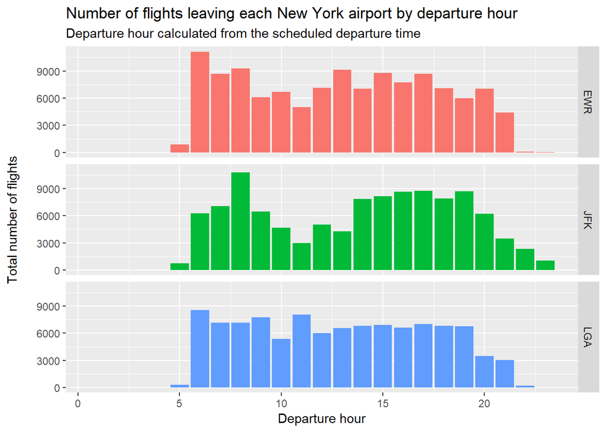

```r
flights %>%
  mutate(
    dep_hour = sched_dep_time %/% 100
  ) %>%
  group_by(origin, dep_hour) %>%
  summarise(
    number_flights = n()
  ) %>%
  ggplot(aes(dep_hour, number_flights, fill = origin)) +
  geom_col(show.legend = FALSE) +
  facet_grid(rows = vars(origin)) +
  labs(
    title = "Number of flights leaving each New York airport by departure hour",
    subtitle = "Departure hour calculated from the scheduled departure time",
    x = "Departure hour",
    y = "Total number of flights\n"
  )
```

## Problem 2

Please write code that completes the following:

- Determine the number of destinations for each NYC airport
- Create a bar chart that depicts the number of destinations
- Color the bars based on the departure airport
- Order the bars from smallest to largest number of destinations (This is called a Pareto Chart)
- It is not required that your graph replicate the graph labels. We will cover that in Chapter 28.

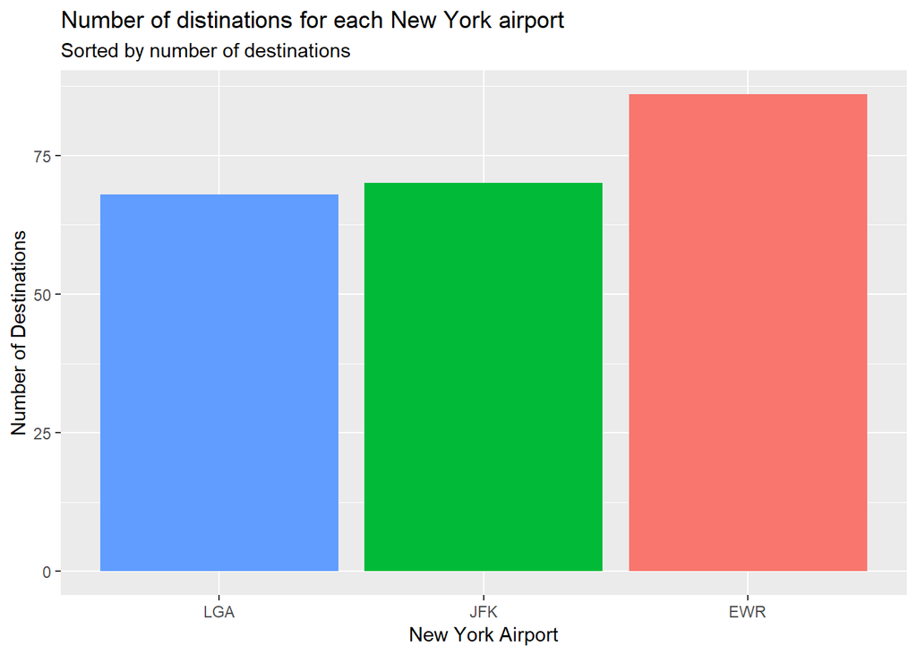

```r
flights %>%
  group_by(origin) %>%
  summarise(
    destinations = n_distinct(dest)
  ) %>%
  ggplot(aes(x = reorder(origin, destinations, FUN = sum), y = destinations)) +
  geom_col(aes(fill = origin), show.legend = FALSE) +
  labs(
    title = "Number of distinations for each New York airport",
    subtitle = "Sorted by number of destinations",
    x = "New York Airport",
    y = "Number of Destinations"
  )
```